# DATA 624 - Homework 8

OMER OZEREN

Exercises 7.2 & 7.5

```r
library(mlbench)
library(caret)
library(earth)
library(kernlab)
library(nnet)
library(ggplot2)
library(mice)
library(AppliedPredictiveModeling)
library(magrittr)
library(corrplot)
library(PerformanceAnalytics)
```

## 7.2

### Load Data

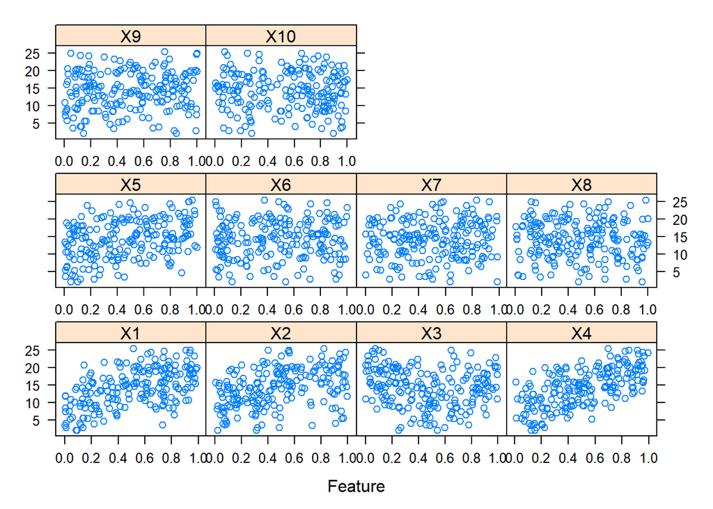

```r
set.seed(42)
trainingData <- mlbench.friedman1(200, sd = 1)
trainingData$x <- data.frame(trainingData$x)
featurePlot(trainingData$x, trainingData$y)
```

```r
testData <- mlbench.friedman1(5000, sd = 1)
testData$x <- data.frame(testData$x)
```

Let’s tune model parameters by using GridSearch

```r
evaluation = function(method, gridSearch = NULL)
{
  Model = train(x = trainingData$x, y = trainingData$y, method = method, tuneGrid = gridSearch, preProcess = c('center', 'scale'), trControl = trainControl(method='cv'))
  Pred = predict(Model, newdata = testData$x)
  performance = postResample(Pred, testData$y)
  print(performance)
}
```

### KNN Model Performace

```r
knn_rst = evaluation('knn')
```

```
##      RMSE  Rsquared       MAE
## 3.0850456 0.6333506 2.4435998
```

### Neural Net Perforance

```r
nnetGrid = expand.grid(decay = c(0,0.01, .1), size = c(1:10))
net_rst = evaluation('nnet', nnetGrid)
```

```
##     RMSE Rsquared      MAE
## 14.31734       NA 13.40039
```

### SVM Performace

```r
library(mlbench)
svm_rst = evaluation('svmRadial')
```

```
##      RMSE  Rsquared       MAE
## 2.3206365 0.7888815 1.7814575
```

### MARS Performance

```r
marsGrid = expand.grid(degree = 1:2, nprune = 2:15)
mars_rst = evaluation('earth', marsGrid)
```

```
##      RMSE  Rsquared       MAE
## 1.2730567 0.9365257 1.0126842
```

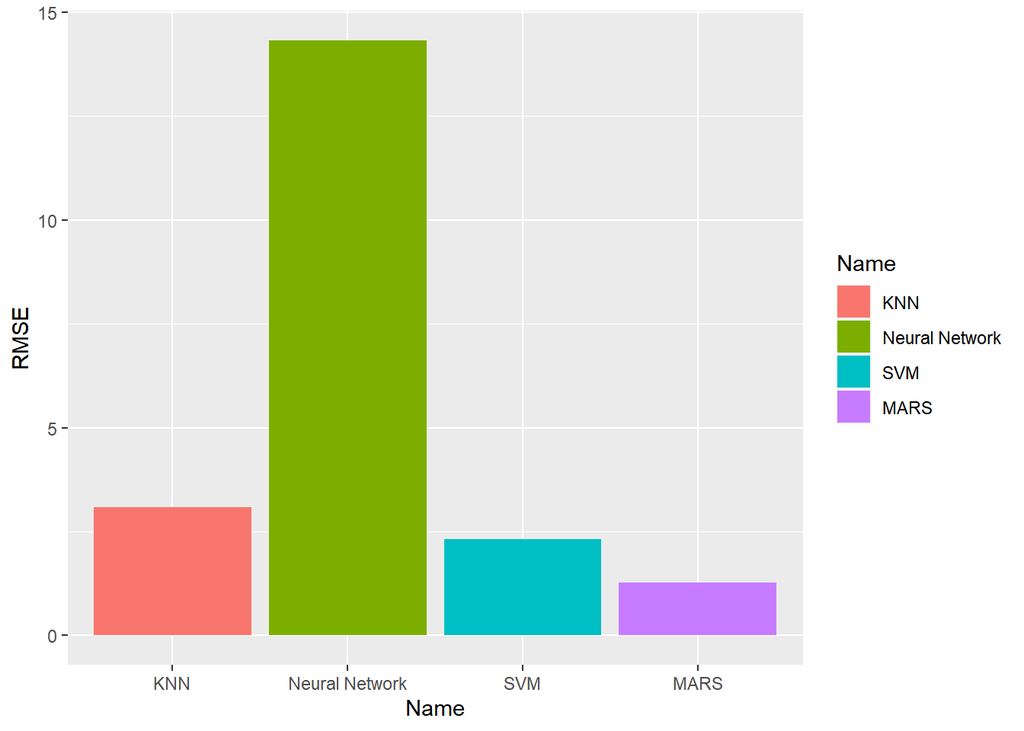

```r
df_performance = rbind(data.frame(Name = 'KNN', RMSE = knn_rst[1]), data.frame(Name= 'Neural Network', RMSE = net_rst[1]) , data.frame(Name = 'SVM', RMSE =svm_rst[1]), data.frame(Name = 'MARS', RMSE = mars_rst[1]))
ggplot() +
  geom_bar(data = df_performance, aes(x = Name, y = RMSE, fill=Name), stat="identity")
```

### Which models appear to give the best performance?

**As we can see from above graph, The MARS model outpreform among all the other models.The model performance metric RMSE gives minimum result for MARS model.**

### Does MARS select informative predictors (those named X1-X5)

```r
marsGrid = expand.grid(degree = 1:2, nprune = 2:15)
MARSModel = train(x = trainingData$x, y = trainingData$y, method = 'earth', tuneGrid = marsGrid, preProcess = c('center', 'scale'), trControl = trainControl(method='cv'))
varImp(MARSModel)
```

```
## earth variable importance
##
##    Overall
## X4  100.00
## X1   63.04
## X2   40.92
## X5   18.90
## X3    0.00
```

**The graph at above shows ranking /feature importance results for variables X1- X5.As we can review X4 (100) is highest ranked feaure,next X1 (63.04), X2 (40.92), X5 (18.90) nad X3 (0.00)**

## 7.5

Exercise 6.3 describes data for a chemical manufacturing process. Use the same data imputation, data splitting, and pre-processing steps as before and train several nonlinear regression models.

### Prepare Data

```r
set.seed(42)
data(ChemicalManufacturingProcess)
chem_data <- ChemicalManufacturingProcess
chem_imputed <- preProcess(chem_data[,2:ncol(chem_data)], method=c('knnImpute')) # KNN imputation for NaN values
chem_data <- cbind(chem_data$Yield,predict(chem_imputed, chem_data[,2:ncol(chem_data)]))
colnames(chem_data)[1] <- "Yield"
#split  train and test data into 70/30
n <-  floor(0.70 * nrow(chem_data))
idx <- sample(seq_len(nrow(chem_data)), size = n)
train <- chem_data[idx, ]
test <- chem_data[-idx, ]
```

### Model Evaluation Function

```r
evaluation = function(method, gridSearch = NULL)
{
  Model = train(x = train[,-1], y = train$Yield, method = method, tuneGrid = gridSearch, preProcess = c('center', 'scale'), trControl = trainControl(method='cv'))
  Pred = predict(Model, newdata = test[,-1])
  performance = postResample(Pred,  test$Yield)
  print(performance)
}
```

### KNN Model Performace

```r
knn_rst = evaluation('knn')
```

```
##      RMSE  Rsquared       MAE
## 1.2758531 0.5315532 1.0397736
```

### Neural Net Perforance

```r
nnetGrid = expand.grid(decay = c(0,0.01, .1), size = c(1:10))
net_rst = evaluation('nnet', nnetGrid)
```

```
##     RMSE Rsquared      MAE
## 39.24164       NA 39.20038
```

### SVM Performace

```r
library(mlbench)
svm_rst = evaluation('svmRadial')
```

```
##      RMSE  Rsquared       MAE
## 1.1463921 0.6880977 0.9427456
```

### MARS Performance

```r
marsGrid = expand.grid(degree = 1:2, nprune = 2:15)
mars_rst = evaluation('earth', marsGrid)
```

```
##      RMSE  Rsquared       MAE
## 0.9520777 0.7362918 0.8203221
```

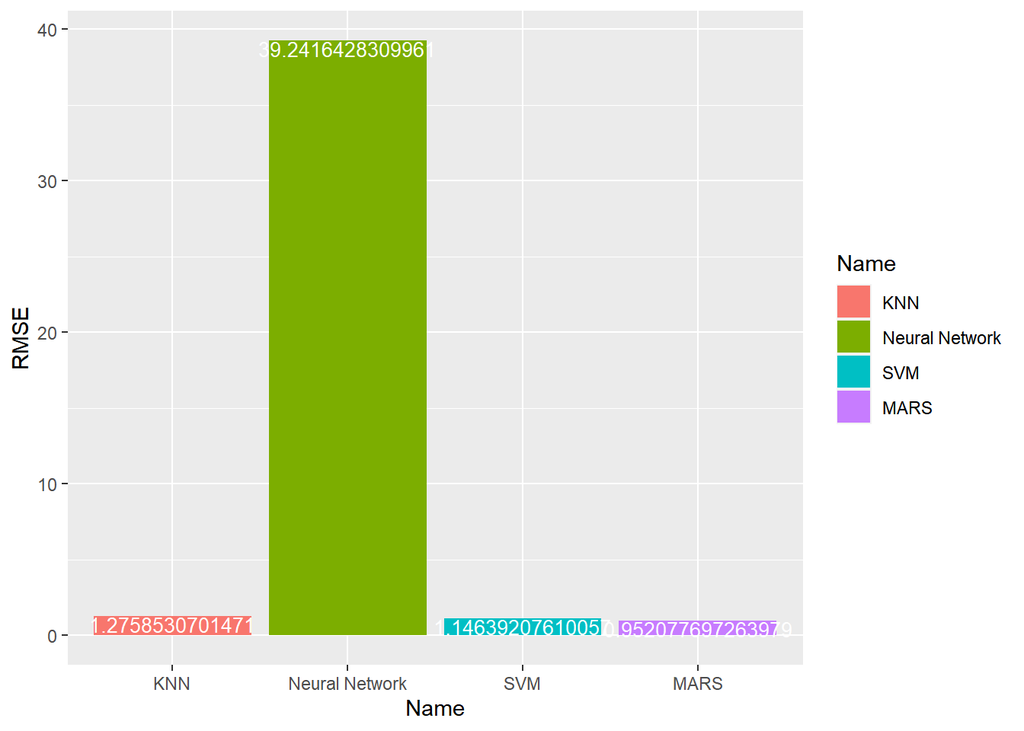

```r
df_performance= rbind(data.frame(Name = 'KNN', RMSE = knn_rst[1]), data.frame(Name= 'Neural Network', RMSE = net_rst[1]) , data.frame(Name = 'SVM', RMSE = svm_rst[1]), data.frame(Name = 'MARS', RMSE = mars_rst[1]))
ggplot(data =df_performance, aes(x = Name, y = RMSE, fill=Name)) +
  geom_bar(stat="identity", position=position_dodge()) +
  geom_text(aes(label=RMSE), vjust=1, color="white",
            position = position_dodge(0.9), size=3.5)
```

### A

Which nonlinear regression model gives the optimal resampling and test set performance?

#### ANSWER :

As we can see from above graph, The MARS model outperform among all the other models.The model performance metric RMSE gives minimum result for MARS model.

### B

Which predictors are most important in the optimal nonlinear regression model? Do either the biological or process variables dominate the list? How do the top ten important predictors compare to the top ten predictors from the optimal linear model?

```r
marsGrid = expand.grid(degree = 1:2, nprune = 2:38)
MARSModel = train(x = train[,-1], y = train$Yield, method = 'earth', tuneGrid = marsGrid, preProcess = c('center', 'scale'), trControl = trainControl(method='cv'))
varImp(MARSModel)
```

```
## earth variable importance
##
##                        Overall
## ManufacturingProcess32  100.00
## ManufacturingProcess09   32.62
## ManufacturingProcess13    0.00
```

#### ANS:

```r
summary(MARSModel)
```

```
## Call: earth(x=data.frame[123,57], y=c(38.66,38.67,3...), keepxy=TRUE, degree=1,
##             nprune=4)
##
##                                     coefficients
## (Intercept)                            38.781735
## h(-1.02888-ManufacturingProcess09)     -1.354290
## h(-1.27561-ManufacturingProcess13)      3.705496
## h(ManufacturingProcess32- -1.10694)     1.147357
##
## Selected 4 of 21 terms, and 3 of 57 predictors (nprune=4)
## Termination condition: RSq changed by less than 0.001 at 21 terms
## Importance: ManufacturingProcess32, ManufacturingProcess09, ...
## Number of terms at each degree of interaction: 1 3 (additive model)
## GCV 1.711083    RSS 187.1897    GRSq 0.5122766    RSq 0.5590697
```

### C

Explore the relationships between the top predictors and the response for the predictors that are unique to the optimal nonlinear regression model. Do these plots reveal intuition about the biological or process predictors and their relationship with yield?

#### ANS:

I’m going to plot correlation plot to see relationships

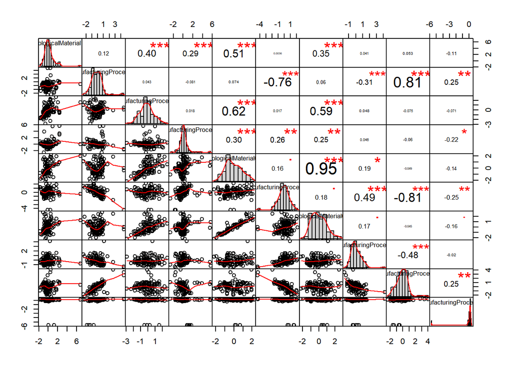